# Technical Report-Extension to Summary Report

Technical Report-Extension to Summary Report Mahrukh Khan 2/10/2022

## Introduction

A real estate company needs prediction for a suitable price per night for their newly built apartments in Thailand. The apartments have a stringent accommodation capacity of 2-6 people. For precise prediction of charges per night I used OLS Linear Regression and three machine learning algorithms: Lasso, Random Forest and Gradient Boosting Method. RMSE was used as the loss function to measure performance fit of the models.

**This report is a supporting document for the summary report.**

## Data Cleaning

### Feature Engineering: Factor Variables

I filtered the data for accommodation of 2 to 6 people. I filtered for property types that had the word ‘apartment’, ‘condominium’ and ‘entire rental units’. I took this decision because (a) condos and apartments are structurally very similar (b) entire rental units was a significant part of my data and if it’s accommodating a maximum of 6 people, then the structure could be very similar. I decided to keep room type in three categories despite having less values for shared room.

### Feature Engineering: Numerical

I created variables such as response rate of a host, days since first review and period of owner becoming a host. I had to clean the ‘number of bathrooms’ variable as it had text and was in character format. I created numeric columns for number of guests, bathrooms, bedrooms, beds, minimum nights bookable, reviews and other review scores linked variables. In the end, I created dummy variable for whether the host was a super host, had been verified and if the property was instantly bookable.

**Amenities**

One of the most challenging parts of cleaning this dataset was to create binary columns for amenities. I first decided to view the various amenities by un-listing the vector and looking at the unique values. The code is provided in the first line of the chunk. Using my domain knowledge and the unique variables, I decided to keep those which could bring variation in predicted price per night of an apartment. In the amenities’ column, I first split the strings by a comma and then removed all the extra symbols whilst lowering casing the entire value. This converted the vector purely into a string input from which I could now easily extract amenities using the grepl command.

```r
#unique(gsub("[^a-zA-Z]", "", unlist(strsplit(data$amenities,','))))

data$amenities <- strsplit(data$amenities, ',')
data$amenities <- tolower(gsub("[^a-zA-Z]", "", data$amenities))

at <- list(
  d_long_term_stay = "longtermstaysallowed",
  d_parking_on_premise = "parkingonpremises",
  d_coffee_maker = "coffeemaker",
  d_dark_shades = 'darkeningshades',
  d_pool = 'pool|hottub',
  d_outdoor = 'patio|balcony|backyard|beachfront',
  d_stream = 'netflix|chromecast',
  d_tv = 'apple|hdtv|tv',
  d_bidet = 'bidet',
  d_workspace='workspace',
  d_gym='gym',
  d_fireplace='fireplace',
  d_kitchen='kitchen',
  d_wifi='wifi')

for(x in names(at)) data[[x]] <- ifelse(grepl(at[[x]], data$amenities)==TRUE,1,0)
```

### Cleaning Target Variable

The price variable was converted into dollars form Thai baht. I thought it would be easier to compare prices with USD. The cleaning of the variable is shown below. I had to remove the dollar sign and the comma after which it was converted into a numeric variable. I filtered for price values between 10 to 1000 dollars as I felt it was sensible to have values between this range.

```r
#Clean daily usd_price variable

data$usd_price <- str_sub(data$price,2)
data$usd_price <- gsub(",","",data$usd_price)
data$usd_price <- as.numeric(data$usd_price)

#The usd_price has originally been give in thai baht and needs to be converted to dollars
data$usd_price <- data$usd_price*0.030

price_datasum <- datasummary(usd_price ~ Mean + Median + Min + Max + P25 + P75 , data = data )

data <- data %>%
  mutate(ln_usd_price = log(usd_price))
data <- data %>%
  filter(usd_price<1000) %>%
  filter(usd_price>10)
```

[output not shown]

### Missing Values

I took four of the approaches listed below to deal with missing values.

**1. Drop:** I only dropped rows that had price as a missing value.

**2. Replace when few missing values:** For missing values in number of bathrooms, I replaced it with the median value that is 1. I assumed that any apartment would at least have one bathroom. For missing values, if number of beds I replaced it with the number of guests that apartment can accommodate. For bedrooms I replaced it with 1, as any apartment catering 2-6 people would have one bedroom at least. Missing values for minimum nights and number of reviews were replaced with 1.

**3. Drop Columns that are not important:** I decided to drop the columns representing various review scores and host response rate. This is because they had over 30% missing values in the entire data each. As I already had two review scores variables and those representing the host as well, I decided to drop these columns.

**4. Replacing with flags:** I added flags for values missing for reviews and variable representing time period since the owner became a host. I also added log of review scores rating after testing its pattern of association with the target variable.

## Price Distribution

This was a key step in selecting the functional form of our target variable. Level price plot shows right tailed skewness, whereas log of price showed a normal distribution. After testing out the models with both the forms, I decided to move forward with level price as there wasn’t a significant difference and it’s easier for interpretability.

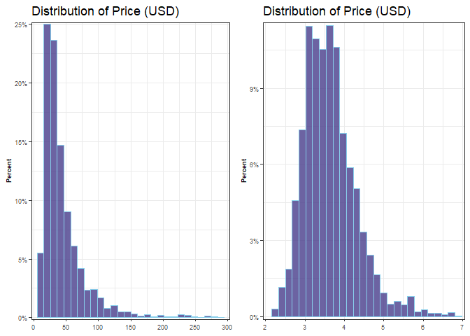

## Patterns of Association

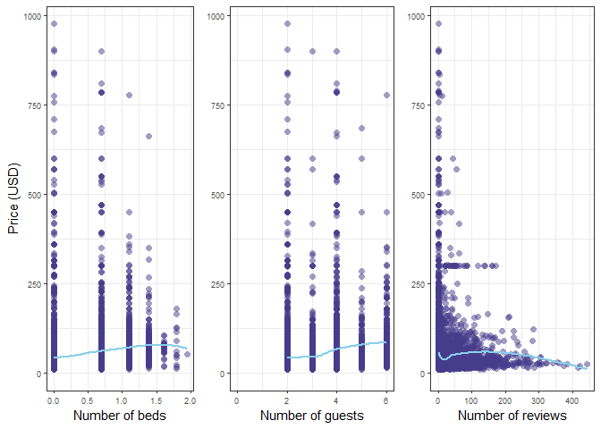

## Interaction Terms:

Using domain knowledge and observing trends of certain predictor variables, interaction terms have carefully been selected. The process involved interacting various amenities with categories of properties and rooms. For instance, if the type of property had parking on its premises or had access to a kitchen. Variation of average price per night within some categories was observed, hence they’ve been included in our complex model.

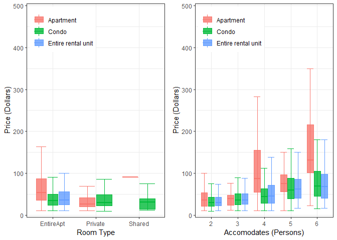

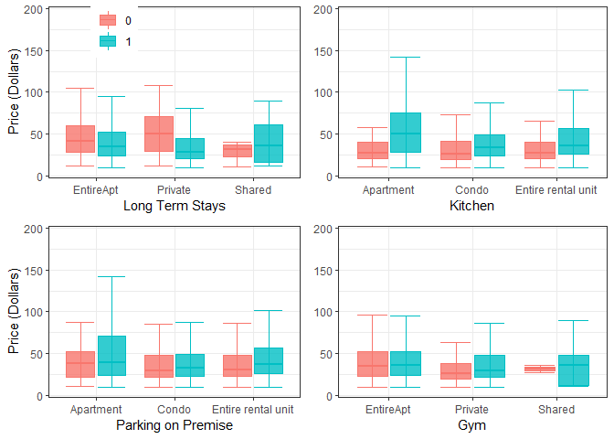

## Splitting the data

Selecting train and holdout samples for the prediction. I split the data into 70 percent that is 6316 observations in the training set and 30% that is 2704 in the holdout set.I conducted a 5 fold cross validation. In the code chunk below, you can view how all three models were made.

```r
# create train and holdout samples -------------------------------------------
# train is where we do it all, incl CV

set.seed(2801)
train_indices <- as.integer(createDataPartition(data$usd_price, p = 0.7, list = FALSE))
data_train <- data[train_indices, ]
data_holdout <- data[-train_indices, ]

# Check the number of observations
dim(data_train)
dim(data_holdout)

# Define models: simpler -> extended

# Basic Variables inc neighborhood
basic_vars <- c( "n_accommodates","n_accommodates2", "n_beds","n_beds2", "n_minimum_nights", "n_days_since",
                 "n_host_since","f_property_type","f_room_type","n_bedrooms", "f_neighbourhood_cleansed",
                 "n_bathroom")

# reviews
reviews <- c("n_number_of_reviews", "n_number_of_reviews2", "flag_n_number_of_reviews" ,
             "ln_review_scores_rating", "flag_review_scores_rating")

# Dummy variables
amenities <-  grep("^d_.*", names(data), value = TRUE)

#interactions for the LASSO and OLS

X1  <- c("n_accommodates*f_property_type",  "f_room_type*f_property_type",  "f_room_type*d_long_term_stay",
        "d_gym*f_property_type", "d_kitchen*f_room_type", "d_parking_on_premise*f_property_type")

# with neighbourhoods
X2  <- c("f_property_type*f_neighbourhood_cleansed", "f_room_type*f_neighbourhood_cleansed",
         "n_accommodates*f_neighbourhood_cleansed" )

predictors_1 <- c(basic_vars)
predictors_2 <- c(basic_vars, reviews, amenities)
predictors_E <- c(basic_vars, reviews, amenities, X1,X2)
```

**After finalizing the models, various algorithms were tested to see which produced the most suitable prediction. Since all the model details have been provided in the summary report, I will not elaborate on it here. Investigations of models not mentioned in other report have been added here.**

## Random Forest - Sub Samples

A further investigation was done to check the performance of the random forest model.

Perfomance across subsamples

| Var.1 | RMSE | Mean.usd_price | RMSE.usd_price |
| --- | --- | --- | --- |
| Apartment size | NA | NA | NA |
| large apt | 58.46136 | 72.03082 | 0.8116159 |
| small apt | 41.42644 | 41.59010 | 0.9960649 |
| Type | NA | NA | NA |
| Apartment | 88.24623 | 78.14014 | 1.1293328 |
| Condo | 42.39950 | 45.31494 | 0.9356628 |
| Entire rental unit | 40.25678 | 49.60198 | 0.8115961 |
| Neighborhood | NA | NA | NA |
| Bang Rak | 100.74691 | 93.97361 | 1.0720766 |
| Khlong San | 49.65131 | 63.67800 | 0.7797248 |
| Phra Khanong | 20.04270 | 30.55463 | 0.6559626 |
| Vadhana | 33.62452 | 59.83036 | 0.5619976 |
| All | 46.63579 | 49.79694 | 0.9365193 |

## CART: Regression Tree

TThe regression tree built with CART results in keeping the most important predictor variables and showcases their interaction terms. The tree first splits in number of bedrooms. It then takes a split for number of reviews and interaction term of neighborhood with Bang Rak. It also splits further based on the host since variable. The in built pruning sets a lenient stopping rule but erases final splits one by one to lower the RMSE in the test set.

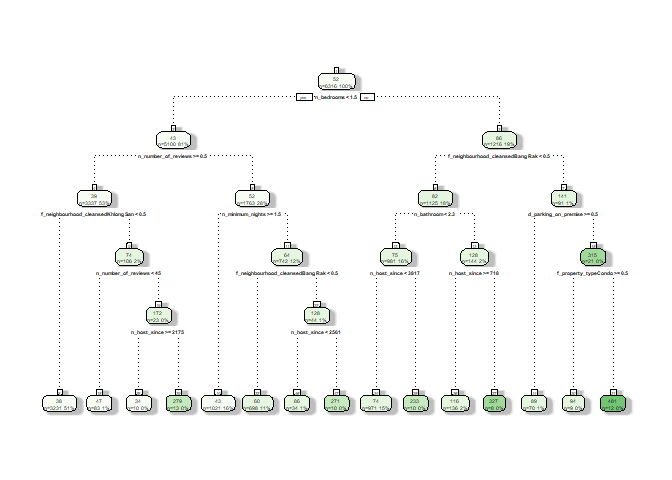

## Tuning GBM Models

I decided to experiment by changing the tuning parameters of GBM Model 2 as shown in the chunk below. I wanted to give various inputs for reducing the impact of each additional tree to improve the model by taking multiple steps. The first model had a learning 0.1 whereas the second used various values between 0.01 and 0.5. The rest of the parameters were kept same that is 250 number of trees and 20 minimum number of training set samples in a node. We can see in the gbm model 2 result that the optimal parameter is of 0.1 as it has the lowest RMSE.

```r
#GBM Model with broad shrinkage

gbm_grid2 <-  expand.grid(interaction.depth = 5, # complexity of the tree
                         n.trees = 250, # number of iterations, i.e. trees
                         shrinkage = c(0.01, 0.05, 0.1, 0.15, 0.5), # learning rate: how quickly the algorithm adapts
                         n.minobsinnode = 20 # the minimum number of training set samples in a node to commence splitting
)

set.seed(1234)
system.time({
  gbm_model2 <- train(formula(paste0("usd_price ~", paste0(predictors_2, collapse = " + "))),
                     data = data_train,
                     method = "gbm",
                     trControl = train_control,
                     verbose = FALSE,
                     tuneGrid = gbm_grid2)
})
```

```
## Stochastic Gradient Boosting
##
## 6316 samples
##   34 predictor
##
## No pre-processing
## Resampling: Cross-Validated (5 fold)
## Summary of sample sizes: 5053, 5054, 5052, 5054, 5051
## Resampling results across tuning parameters:
##
##   shrinkage  RMSE      Rsquared   MAE
##   0.01       61.06741  0.1770366  26.54442
##   0.05       58.62465  0.2276563  25.39458
##   0.10       58.48166  0.2328243  26.16016
##   0.15       59.00373  0.2237266  26.90689
##   0.50       63.52408  0.1808363  33.60570
##
## Tuning parameter 'n.trees' was held constant at a value of 250
## Tuning
##  parameter 'interaction.depth' was held constant at a value of 5
##
## Tuning parameter 'n.minobsinnode' was held constant at a value of 20
## RMSE was used to select the optimal model using the smallest value.
## The final values used for the model were n.trees = 250, interaction.depth =
##  5, shrinkage = 0.1 and n.minobsinnode = 20.
```

## Conclusion (holdout set)

Horse Race of Models Holdout RSME

|  | Holdout RMSE |
| --- | --- |
| OLS | 58.38303 |
| OLS (model w/ amenities and reviews) | 63.28533 |
| OLS (model w/ interactions) | 59.56840 |
| LASSO (model w/ interactions) | 57.35238 |
| CART | 51.19502 |
| Random forest 1: smaller model | 47.54792 |
| Random forest 2: extended model | 46.63579 |
| GBM (basic tuning) | 45.69617 |
| GBM (broad tuning) | 45.99311 |

The reduction in RMSE overall in the holdout set as compared to the training set can be observed here. This differential might exist due to the varying sample sizes or over fitting of the variables on the training set. The difference is not too significant, hence we can say that the model performance meets our requirements. The best fit model is GBM (basic tuning) for the entire data set. In case we have high external validity, we can expect to make a 45.7 dollars error when using our model on live data. Whereas GBM does give a slightly better prediction, the advantage of using random forest algorithm is that variables can be studied in more depth with diagnostic tools